# Project2

Zeyu Li

2023-09-30

# Prepare packages

```r
library("tidyverse")
library("tidytuesdayR")
library("here")
```

```r
library("lubridate")
library("ggplot2")
```

# Part 1: Fun with functions

### Part 1A: Exponential transformation

```r
Exp <- function(x, k) {
  result <- 1
  for (i in 1:k) {
      result <- result + (x ^ i)/factorial(i)
  }
  print(result)
}

#test
Exp(3,2)
```

```
## [1] 8.5
```

```r
Exp(4,15)
```

```
## [1] 54.59788
```

### Part 1B: Sample mean and sample standard deviation

```r
sample_mean <- function(x) {
  Sum <- 0
  for (i in x) {
    Sum <- Sum + i
  }
  Sum/length(x)
}

sample_sd <- function(x) {
  a <- 0
  for (i in x) {
    a <- a + (i-sample_mean(x))^2
  }
  s2 <- a/(length(x)-1)
  s <- sqrt(s2)
  s
}

#test
j <- c(1:10)
sample_mean(j)
```

```
## [1] 5.5
```

```r
mean(j, na.rm = T) #To test if we can get the same value as standard method
```

```
## [1] 5.5
```

```r
sample_sd(j)
```

```
## [1] 3.02765
```

```r
sd(j, na.rm = T) #To test if we can get the same value as standard method
```

```
## [1] 3.02765
```

### Part 1C: Confidence intervals

```r
calculate_CI <- function(x, conf = 0.95) {
  alpha <- 1 - conf
  degrees_freedom <- length(x) - 1
  t_score <- qt(p = alpha / 2, df = degrees_freedom, lower.tail = FALSE)
  a <- sample_mean(x) - t_score * sample_sd(x)/sqrt(length(x))
  b <- sample_mean(x) + t_score * sample_sd(x)/sqrt(length(x))
  c(lower_bound = a, upper_bound = b)
}

#test
#my function
data("airquality")
x <- airquality$Temp
calculate_CI(x, conf = 0.95)
```

```
## lower_bound upper_bound
##    76.37051    79.39420
```

```r
calculate_CI(x, conf = 0.90)
```

```
## lower_bound upper_bound
##    76.61596    79.14875
```

```r
calculate_CI(x, conf = 0.99)
```

```
## lower_bound upper_bound
##    75.88623    79.87848
```

```r
#standard method
dat <- data.frame(x = x)
fit <- lm(x ~ 1, dat)
confint(fit, level = 0.95)
```

```
##                2.5 %  97.5 %
## (Intercept) 76.37051 79.3942
```

```r
confint(fit, level = 0.90)
```

```
##                  5 %     95 %
## (Intercept) 76.61596 79.14875
```

```r
confint(fit, level = 0.99)
```

```
##                0.5 %   99.5 %
## (Intercept) 75.88623 79.87848
```

# Part 2: Wrangling data

```r
if (!dir.exists(here("data"))) {
    dir.create(here("data"))
}

if (!file.exists(here("data", "tuesdata_rainfall.RDS"))) {
    tuesdata <- tidytuesdayR::tt_load("2020-01-07")
    rainfall <- tuesdata$rainfall
    temperature <- tuesdata$temperature

    # save the files to RDS objects
    saveRDS(tuesdata$rainfall, file = here("data", "tuesdata_rainfall.RDS"))
    saveRDS(tuesdata$temperature, file = here("data", "tuesdata_temperature.RDS"))
}

rainfall <- readRDS(here("data", "tuesdata_rainfall.RDS"))
temperature <- readRDS(here("data", "tuesdata_temperature.RDS"))

glimpse(rainfall)
```

```
## Rows: 179,273
## Columns: 11
## $ station_code <chr> "009151", "009151", "009151", "009151", "009151", "009151…
## $ city_name    <chr> "Perth", "Perth", "Perth", "Perth", "Perth", "Perth", "Pe…
## $ year         <dbl> 1967, 1967, 1967, 1967, 1967, 1967, 1967, 1967, 1967, 196…
## $ month        <chr> "01", "01", "01", "01", "01", "01", "01", "01", "01", "01…
## $ day          <chr> "01", "02", "03", "04", "05", "06", "07", "08", "09", "10…
## $ rainfall     <dbl> NA, NA, NA, NA, NA, NA, NA, NA, NA, NA, NA, NA, NA, NA, N…
## $ period       <dbl> NA, NA, NA, NA, NA, NA, NA, NA, NA, NA, NA, NA, NA, NA, N…
## $ quality      <chr> NA, NA, NA, NA, NA, NA, NA, NA, NA, NA, NA, NA, NA, NA, N…
## $ lat          <dbl> -31.96, -31.96, -31.96, -31.96, -31.96, -31.96, -31.96, -…
## $ long         <dbl> 115.79, 115.79, 115.79, 115.79, 115.79, 115.79, 115.79, 1…
## $ station_name <chr> "Subiaco Wastewater Treatment Plant", "Subiaco Wastewater…
```

```r
glimpse(temperature)
```

```
## Rows: 528,278
## Columns: 5
## $ city_name   <chr> "PERTH", "PERTH", "PERTH", "PERTH", "PERTH", "PERTH", "PER…
## $ date        <date> 1910-01-01, 1910-01-02, 1910-01-03, 1910-01-04, 1910-01-0…
## $ temperature <dbl> 26.7, 27.0, 27.5, 24.0, 24.8, 24.4, 25.3, 28.0, 32.6, 35.9…
## $ temp_type   <chr> "max", "max", "max", "max", "max", "max", "max", "max", "m…
## $ site_name   <chr> "PERTH AIRPORT", "PERTH AIRPORT", "PERTH AIRPORT", "PERTH …
```

Using the `rainfall` and `temperature` data, perform the following steps and create a new data frame called `df`:

1. Start with `rainfall` dataset and drop any rows with NAs.

```r
rainfall <- na.omit(rainfall)
```

2. Create a new column titled `date` that combines the columns `year`, `month`, `day` into one column separated by “-”. (e.g. “2020-01-01”). This column should not be a character, but should be recognized as a date. (**Hint**: check out the `ymd()` function in `lubridate` R package). You will also want to add a column that just keeps the `year`.

```r
rainfall %>%
  mutate(year1 = year) %>%
  unite(col = date, c("year1", "month", "day"), sep = "-") -> rainfall
rainfall$date <- as.Date(rainfall$date)
```

3. Using the `city_name` column, convert the city names (character strings) to all upper case.

```r
rainfall$city_name <- toupper(rainfall$city_name)
```

4. Join this wrangled rainfall dataset with the `temperature` dataset such that it includes only observations that are in both data frames. (**Hint**: there are two keys that you will need to join the two datasets together). (**Hint**: If all has gone well thus far, you should have a dataset with 83,964 rows and 13 columns).

```r
df <- inner_join(rainfall, temperature, by = c("city_name", "date"))
glimpse(df)
```

```
## Rows: 83,964
## Columns: 13
## $ station_code <chr> "009151", "009151", "009151", "009151", "009151", "009151…
## $ city_name    <chr> "PERTH", "PERTH", "PERTH", "PERTH", "PERTH", "PERTH", "PE…
## $ year         <dbl> 1967, 1967, 1967, 1967, 1967, 1967, 1967, 1967, 1967, 196…
## $ date         <date> 1967-07-05, 1967-07-05, 1967-07-06, 1967-07-06, 1967-07-…
## $ rainfall     <dbl> 2.8, 2.8, 4.8, 4.8, 5.8, 5.8, 16.0, 16.0, 1.0, 1.0, 1.0, …
## $ period       <dbl> 1, 1, 1, 1, 1, 1, 1, 1, 1, 1, 1, 1, 1, 1, 1, 1, 1, 1, 1, …
## $ quality      <chr> "Y", "Y", "Y", "Y", "Y", "Y", "Y", "Y", "Y", "Y", "Y", "Y…
## $ lat          <dbl> -31.96, -31.96, -31.96, -31.96, -31.96, -31.96, -31.96, -…
## $ long         <dbl> 115.79, 115.79, 115.79, 115.79, 115.79, 115.79, 115.79, 1…
## $ station_name <chr> "Subiaco Wastewater Treatment Plant", "Subiaco Wastewater…
## $ temperature  <dbl> 17.8, 8.7, 18.4, 8.0, 17.2, 10.5, 16.1, 4.4, 16.8, 4.1, 2…
## $ temp_type    <chr> "max", "min", "max", "min", "max", "min", "max", "min", "…
## $ site_name    <chr> "PERTH AIRPORT", "PERTH AIRPORT", "PERTH AIRPORT", "PERTH…
```

# Part 3: Data visualization

In this part, we will practice our ggplot2 plotting skills within the tidyverse starting with our wrangled df data from Part 2. For full credit in this part (and for all plots that you make), your plots should include:

An overall title for the plot and a subtitle summarizing key trends that you found. Also include a caption in the figure. There should be an informative x-axis and y-axis label. Consider playing around with the theme() function to make the figure shine, including playing with background colors, font, etc.

### Part 3A: Plotting temperature data over time

Use the functions in `ggplot2` package to make a line plot of the max and min temperature (y-axis) over time (x-axis) for each city in our wrangled data from Part 2. You should only consider years 2014 and onwards. For full credit, your plot should include:

1. For a given city, the min and max temperature should both appear on the plot, but they should be two different colors.
2. Use a facet function to facet by `city_name` to show all cities in one figure.

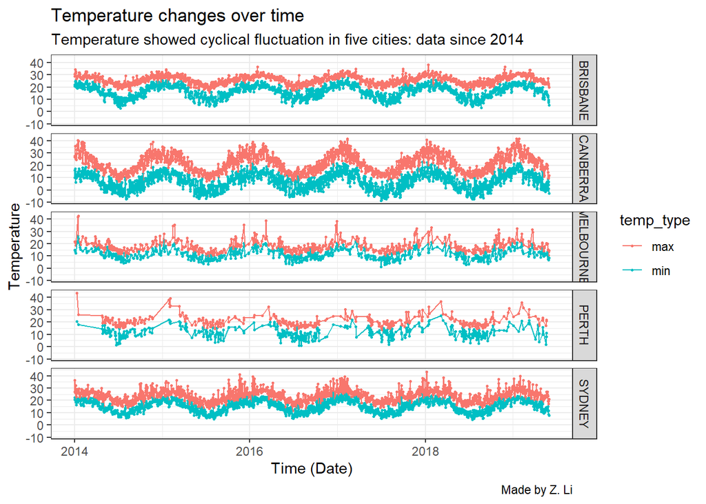

```r
t2 <- filter(df, year >= 2014)
t2 %>%
  ggplot(aes(date, temperature, color = temp_type)) +
  geom_point(size = 0.5) +
  geom_line() +
  facet_grid(city_name~.) +
  theme_bw() +
  labs(title = "Temperature changes over time", subtitle = "Temperature showed cyclical fluctuation in five cities: data since 2014", x = "Time (Date)", y = "Temperature", caption = "Made by Z. Li")
```

### Part 3B: Plotting rainfall over time

#### My function

```r
rain_city_year <- function(x, y) {
  if (length(row.names(filter(df, city_name == x, year == y)))) {
  df %>%
    filter(city_name == x, year == y) %>%
    ggplot(aes(log(rainfall))) +
    geom_histogram() +
    theme_bw() +
    labs(title = paste("Rainfall in", x, "in", y, sep = " "), subtitle = "Rainfall distribution of a specific city in a given year", x = "Rainfall (log scale)", y = "Count", caption = "Made by Z. Li")
  } else
  stop("We can't find the rainfall data of your input. Please input city's name among BRISBANE, CANBERRA, MELBOURNE, PERTH, and SYDNEY, and input a year between 1910 and 2019", call. = FALSE)
}
```

#### Description

1. rain_city_year function is used to produce a single histogram for rainfall in a specific city in a specific year. Two parameters need to be input, so I chose x and y to represent city_name and year, respectively.
2. Two conditions may happen, right input with a plot, and wrong input with an error message, so I use the if…else function. To check if the input combination of city_name and year have measurements, I chose to test the length of the sub-dataset filtered by the combination: if the length is longer than 0, it means there are measurements and a plot can be produced; if not, we need to produce an error message.
3. Then I use the code provided by the professor to produce a plot. To make the plot more readable, I chose the bw theme and added some text, including title, subtitle, x label, y label, and caption. The title is the most important text, I added the information of a specific city and year in the title, so that the reader can see which city and year the rainfall was from.
4. For the error message, I would provide options for “right combinations” for users, so that they can know what to input.

#### Test my function

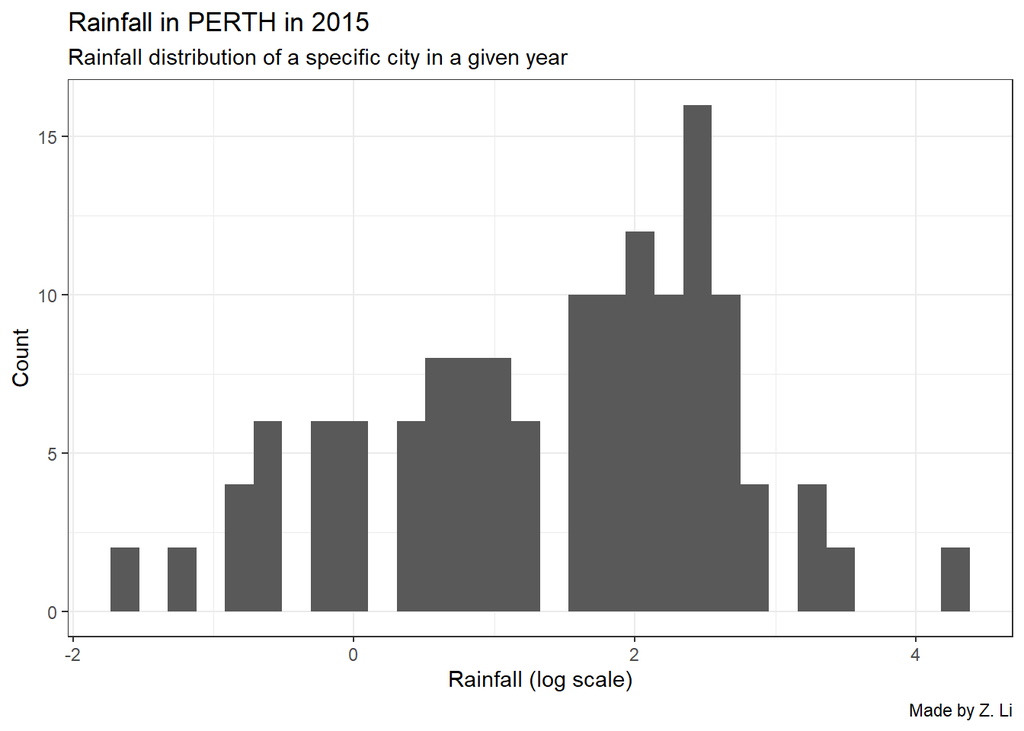

```r
rain_city_year("PERTH", 2015)
```

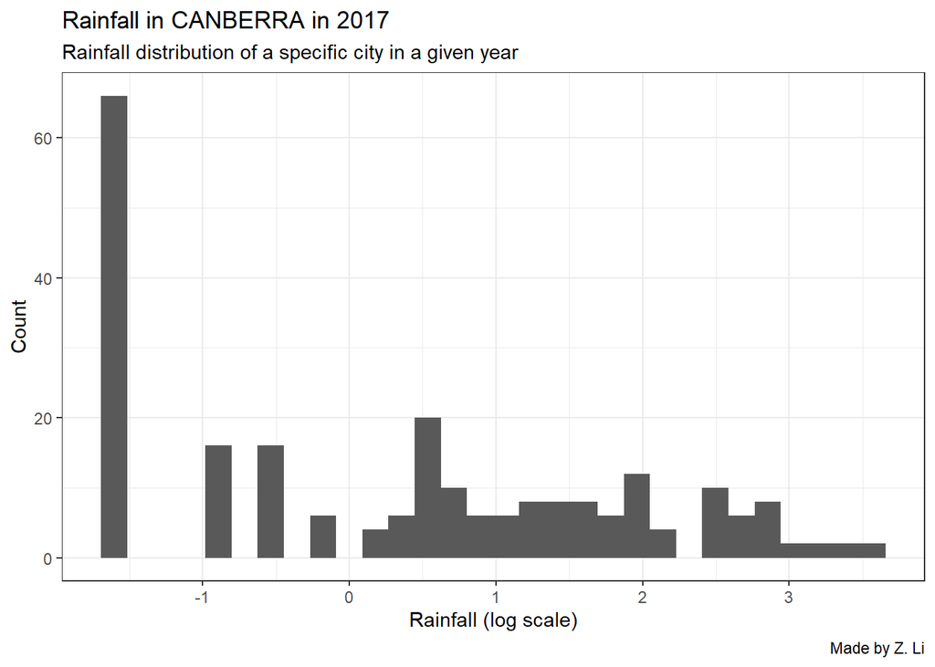

```r
rain_city_year("CANBERRA", 2017)
```